# Predictive Checks + Final Project

## Monday, June 3

Today we will…

- Game Plan Survey
- New Material:
  - Predictive Checks
- Work Time
  - PA 10: MPG and Horsepower?
  - PC4: Linear Regression
  - PC5: Final Report

## Game Plan Survey

Please complete this survey on creating game plans by 11:59pm on Friday!

# Predictive Checks

> Any good analysis should include a check of the “adequacy of the fit of the model to the data and the plausibility of the model…” – Andrew Gelman

## Predictive Checks

Predictive checks allow us to assess if our fitted model would produce data **similar to** the data that we observed.

- Yes? Our model is a good fit.
- No? Our model is not a good fit.

**This is an assessment of model fit.**

**Caution**

Predictive checks are **not** aimed to make predictions of the response variable for new observations of the explanatory variable.

## Recall: Linear Regression

For simple linear regression, we assume the responses can be modeled as **a linear function of the explanatory variable and some error**.

$$y = \beta_0 + \beta_1 x_1 + \varepsilon$$

We also assume that those errors $(\varepsilon)$ follow a **normal distribution with mean 0 and standard deviation $\sigma$**.

$$\varepsilon \sim N(0, \sigma)$$

## Recall: Linear Regression

Therefore, the data **we would expect** to come from this model can be generated by:

1. predicting values from a fitted model ($\hat{y} = \hat{\beta}_0 + \hat{\beta}_1 x_1$) …

**and**

2. … adding normally distributed errors.

## Recall: Linear Regression

This method produces data that perfectly agree with the linear model conditions:

**L**inear relationship between $x$ and $y$.

**I**ndependence of observations.

**N**ormality of residuals.

**E**qual variance of residuals.

## Predictive Checks

If we compare data generated from the linear model to the observed data, we can determine how well the observed data and linear model fit.

- Is it plausible that the observed data could be generated by the model?

## The Process

To perform a predictive check…

1. Fit a regression model to the observed data.
2. For a set of explanatory values, obtain predicted response values from the model.
3. Add random errors to the predictions.
4. Compare the simulated data to the observed data.
5. Iterate!

## The Process

To perform a predictive check…

1. **Fit a regression model to the observed data.**

Use the `lm()` function…

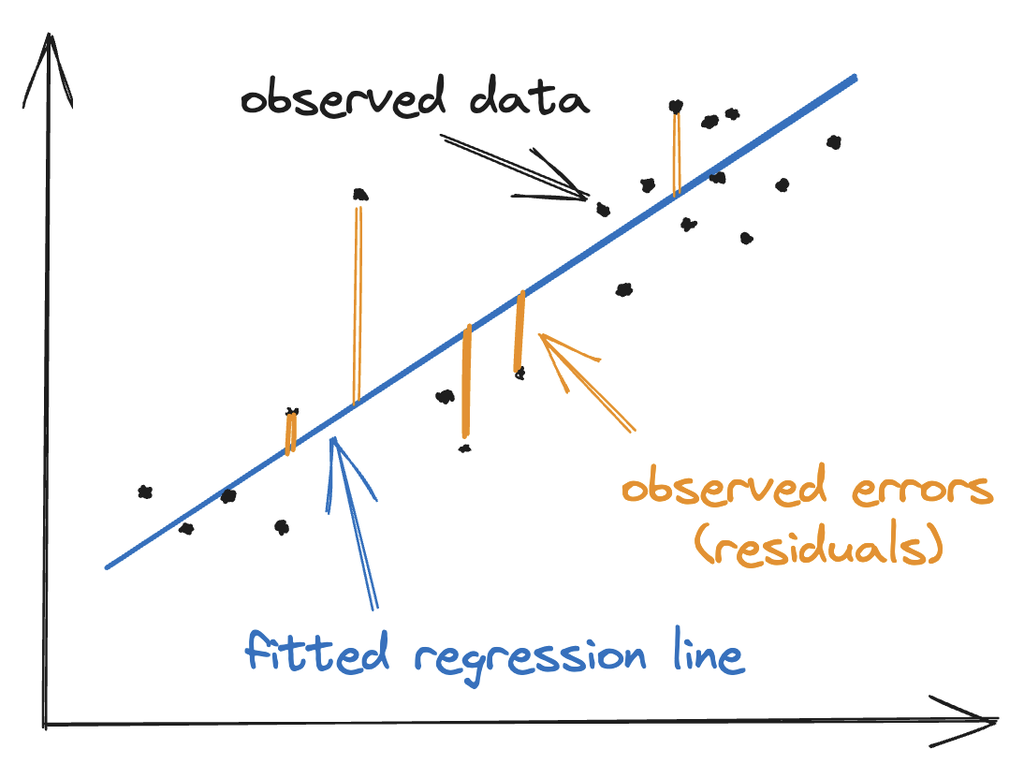

## The Process

To perform a predictive check…

1. Fit a regression model to the observed data.
2. **For a set of explanatory values, obtain predicted response values from the model.**

Use the `predict()` function…

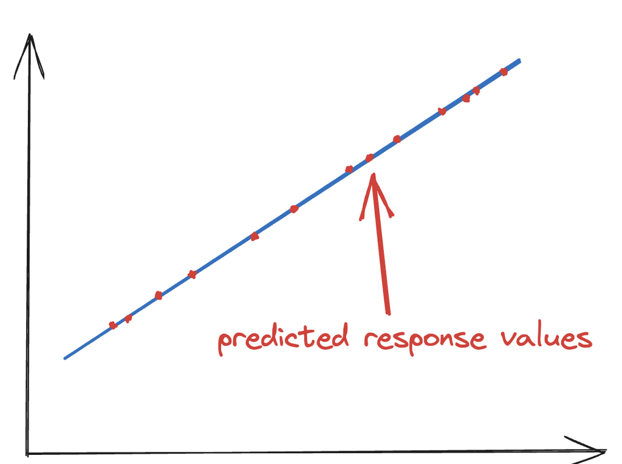

## The Process

To perform a predictive check…

1. Fit a regression model to the observed data.
2. For a set of explanatory values, obtain predicted response values from the model.
3. **Add random errors to the predictions.**

Use the `rnorm()` function…

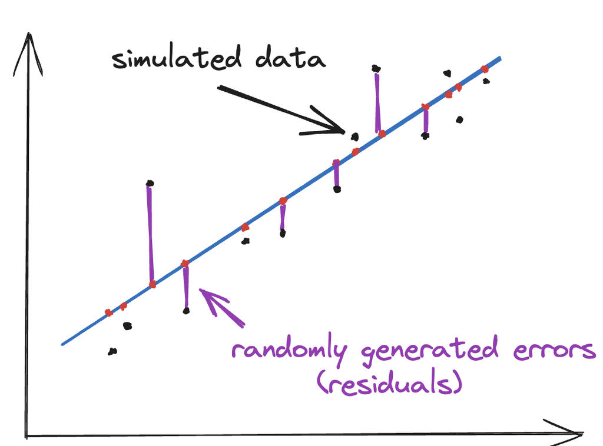

The random errors have mean 0 and standard deviation estimated by the **residual standard error** (use `sigma()`).

## The Process

To perform a predictive check…

1. Fit a regression model to the observed data.
2. For a set of explanatory values, obtain predicted response values from the model.
3. Add random errors to the predictions.
4. **Compare the simulated data to the observed data.**

Use the `lm()` function to regress observed on simulated…

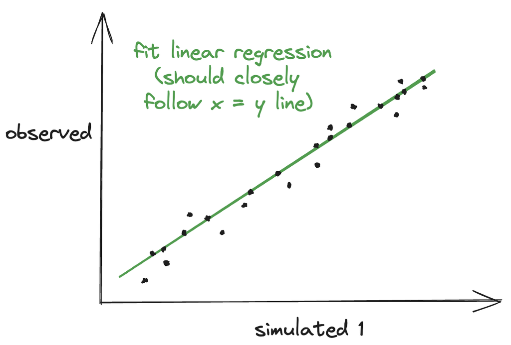

To measure similarity, record $R^2$ (proportion of variability in $y$ explained by a linear relationship with $x$).

## The Process

To perform a predictive check…

1. Fit a regression model to the observed data.
2. For a set of explanatory values, obtain predicted response values from the model.
3. Add random errors to the predictions.
4. Compare the simulated data to the observed data.
5. **Iterate!**

Use the `map()` function to repeat the process over and over…

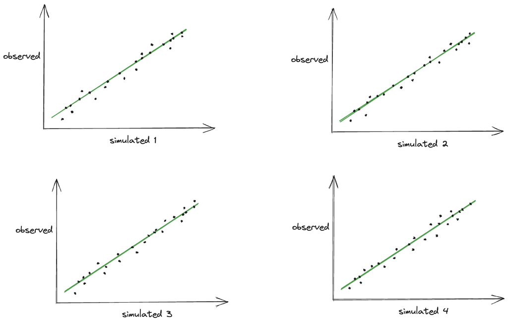

We want to see how the model performs across many simulated datasets.

- Compute the $R^2$ for each.

Instead of $R^2$, could use correlation $(r)$, sum of squared errors $(SSE)$, or the estimate of $\sigma$ $(RMSE)$ to measure similarity.

## Distribution of Simulated $R^2$

Plot the distribution of simulated $R^2$ values to see how well the model performs.

- Values distributed near 1 indicate a good fit!

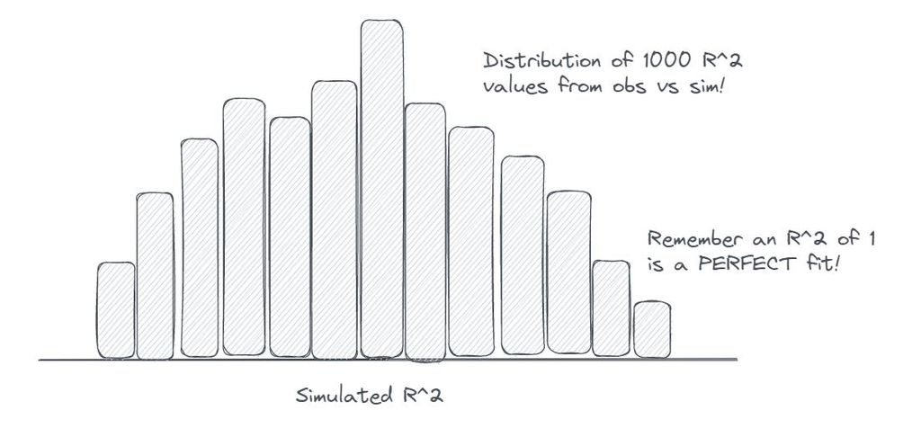

## For your project…

For your group project, you will run predictive checks to assess how well your model performs.

- This is Section 3 of the Project Details page!

## [PA 10: MPG and Horsepower?](https://zoerehnberg.github.io/STAT331-S23/practice_activities/PA_10.html)

Let’s practice implementing *one iteration* of predictive checks.

## To do…

- **PA 10: MPG and Horsepower?**
  - Due **Wednesday, 6/5 at 10:00am**.
- **Course Evaluation**
  - Closes **Friday, 6/7 at 11:59pm**.
- **Final Exam**
  - Monday, 6/10 from 1:10-4:00pm for the 2:10pm section.
  - Tuesday, 6/11 from 7:10-10:00am for the 4:10pm section.
- **Final Project Report**
  - Due **Wednesday, 6/12 at 11:59pm**.

## Wednesday, June 5

Today we will…

- Linear Regression: Feedback
- Final Exam: What to Expect
- Remaining Q & A
- Final Project Work Time

## Linear Regression: Feedback

- Think about the readability of the numbers you are presenting.
  - Do you need 6 decimal places?
  - Is scientific notation easily understood?
- Include **units** on your plots!
- If your data do not look to have a linear relationship, try transforming them!
- If you do any **transformations**, make sure you discuss them.
  - Also make sure they are clear on any plots!

## Linear Regression: Feedback

- When you present a plot or a table, **discuss in words** what you want the reader to take away from it.
  - Discuss the table of variances as part of your discussion of model fit.
- If you are modeling the average across years (or one particular year) make sure you include a plot of the average (or that year) in addition to the full data.
  - Show the data you are using for your linear regression.
- Before implementing linear regression, give an overview of the method and why it is appropriate in this setting.

## Final Exam: What to Expect

- The exam is worth a total of 100 points and has 3 parts: General Questions, Short Answer, and Statistical Modeling.
- You will have 2 hours and 50 minutes for the entire exam.
- You will complete Part 1: General Questions first.
  - This part is closed note and closed computer.
- You can complete the questions in Part 2: Short Answer and Part 3: Statistical Modeling in any order.
  - A .qmd starter file will be opened at the start of each final.
  - I will pass out paper copies of the questions.

## Final Exam: What to Expect

The exam is **cumulative** and will definitely contain questions on:

- Data manipulations with `dplyr` and `tidyr`.
- Data visualizations with `ggplot`.
- Function writing.
- Functional programming with `map`,
- Statistical modeling with `lm`.

## Finals Week Office Hours

Monday 6/10 from 10:00am to 12:00pm!

# Final Exam + Final Project Q & A

## To do…

- **Game Plan Survey!**
- **Course Evaluation**
  - Closes **Friday, 6/7 at 11:59pm**.
- **Final Exam**
  - Monday, 6/10 from 1:10-4:00pm for the 2:10pm section.
  - Tuesday, 6/11 from 7:10-10:00am for the 4:10pm section.
- **Final Project Report**
  - Due **Wednesday, 6/12 at 11:59pm**.